# IODS course project

Sezin Yaman

sezin.yaman@helsinki.fi

## Final Assignment

08.03.2017

Github repository: https://github.com/sgizm/IODS-final

### 1 - General Description and Research Question

This assignment includes the initial analysis of a survey that received 108 responses in a software company. The survey was designed to investigate how software companies involve users in their software development. The survey is part of a larger study that aims to improve capabilities for user involvement in software development. The main research question is to examine how methods for involving the users into development can be improved.

Company representatives were involved in the process at the stage of the survey design. This allowed to identify a number of hypotheses and assumptions that needs to be checked. For instance, the developers and testers are receiving the same information about the end users, therefore their responses to the questions might follow a similar pattern. Secondly, there was a research interest to know whether managers differently than the rest of the roles think about user involvement, as their job function is not as technical as others’. Lastly, in more traditional software development usually UX department is seens as the responsible agent for involving the users. Even though modern development approaches suggest that user involvement shall be done over whole development process by different roles, it will be interesting to capture the results on this point.

Survey in this assignment includes two sections: 1) Background section where the demographics of the respondents are identified, and 2) User involvement state where the current state of the companies are identified. Questions can be seen as below:

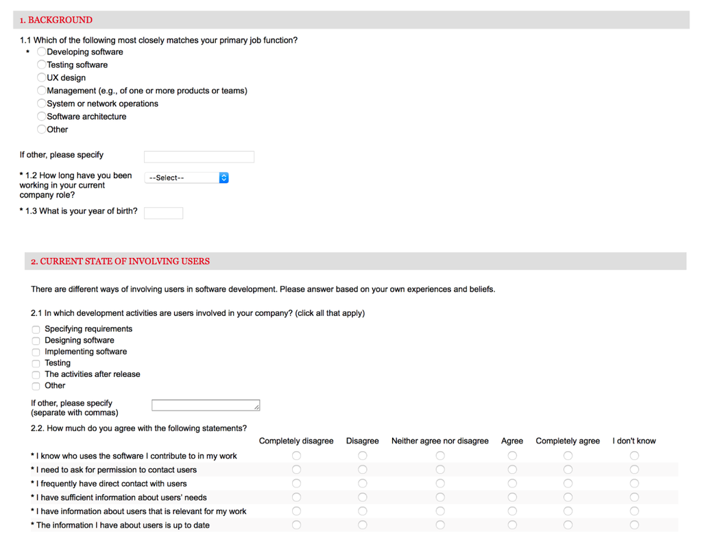

### 2 - Data Wrangling

Data wrangling is done in Final.R file. Here is how it is look like:

```r
data <- read.csv("~/Desktop/Open Data Science/IODS-project/data_final.csv")
View(data)
str(data)
```

```
## 'data.frame':    108 obs. of  35 variables:
##  $ Submission.ID                                                                                                          : int  1 2 3 4 5 6 7 8 9 10 ...
##  $ X1.1.Which.of.the.following.most.closely.matches.your.primary.job.function..                                           : int  5 0 0 6 4 0 3 0 0 1 ...
##  $ X1.2.How.long.have.you.been.working.in.your.current.company.role.                                                      : int  48 60 21 29 30 38 33 35 9 3 ...
##  $ X1.3.What.is.your.year.of.birth.                                                                                       : int  1963 1968 1980 1972 1980 1978 1978 1975 1970 1970 ...
##  $ Specifying.requirements                                                                                                : logi  TRUE TRUE TRUE TRUE TRUE TRUE ...
##  $ Designing.software                                                                                                     : logi  FALSE FALSE TRUE TRUE FALSE FALSE ...
##  $ Implementing.software                                                                                                  : logi  FALSE FALSE TRUE TRUE FALSE FALSE ...
##  $ Testing                                                                                                                : logi  FALSE TRUE TRUE TRUE FALSE FALSE ...
##  $ The.activities.after.release                                                                                           : logi  TRUE TRUE TRUE TRUE FALSE TRUE ...
##  $ Other                                                                                                                  : logi  FALSE FALSE FALSE FALSE FALSE FALSE ...
##  $ X2.2..How.much.do.you.agree.with.the.following.statements...I.know.who.uses.the.software.I.contribute.to.in.my.work    : int  5 3 5 5 3 4 4 5 5 3 ...
##  $ X2.2..How.much.do.you.agree.with.the.following.statements...I.need.to.ask.for.permission.to.contact.users              : int  2 1 2 3 1 1 4 1 1 4 ...
##  $ X2.2..How.much.do.you.agree.with.the.following.statements...I.frequently.have.direct.contact.with.users                : int  5 2 3 4 2 4 4 4 5 2 ...
##  $ X2.2..How.much.do.you.agree.with.the.following.statements...I.have.sufficient.information.about.users..needs           : int  3 2 3 4 2 2 3 5 4 1 ...
```

[output cut: 21 more lines]

```r
dim(data)
```

```
## [1] 108  35
```

### 3 - Exploration and Analysis Method

Here will explore the dataset and we detail on how it can be analyzed further. We start wtih adding the libraries we use and global variables.

To start with the demograhics, we first look at the job functions.

```r
summary(data$jobfunction)
```

```
##        Architecture Developing software          Management
##                  12                  36                  24
##          Operations               Other    Testing software
##                  14                   7                   7
##           UX Design
##                   8
```

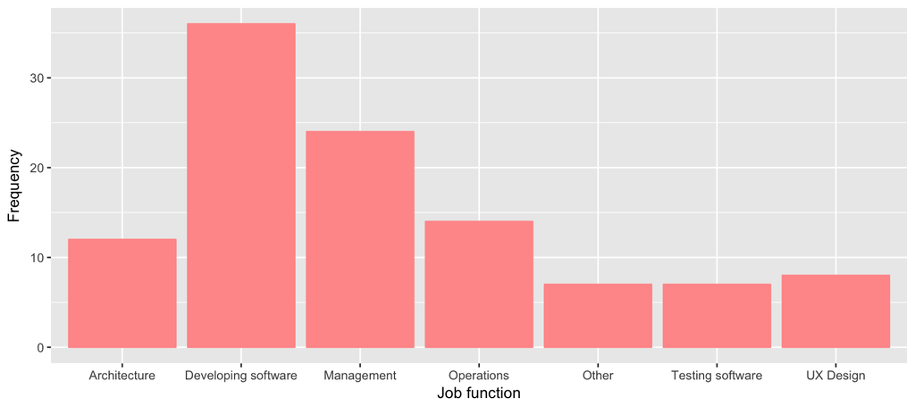

```r
ggplot(data, aes(x=jobfunction)) +
  geom_bar(fill="#FF9999", colour="#FF9999") +
  labs(x="Job function", y="Frequency")
```

We see that majority of the respondents are software developers (36 respondents), followed by managers (24) and people from operations (14) out of total 108. As the interesting questions we want to answer with the survey are related to these roles, the sample seems to be well distributed over roles.

Another demographics to look at could be the age distribution of the respondents:

```r
summary(data$age)
```

```
##    Min. 1st Qu.  Median    Mean 3rd Qu.    Max.
##   22.00   36.00   45.00   44.66   54.00   67.00
```

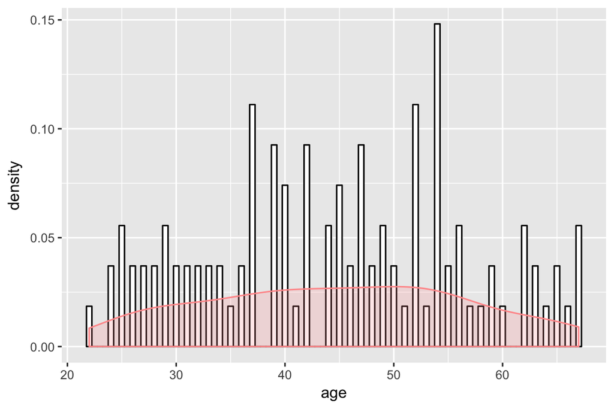

```r
ggplot(data, aes(x=age)) +
  geom_histogram(aes(y=..density..),
                 binwidth=.5,
                 colour="black", fill="white") +
  geom_density(alpha=.2, fill="#FF9999", colour="#FF9999")
```

```r
summary(data$worktime)
```

```
##    Min. 1st Qu.  Median    Mean 3rd Qu.    Max.
##    0.00   14.00   25.50   23.59   33.00   60.00
```

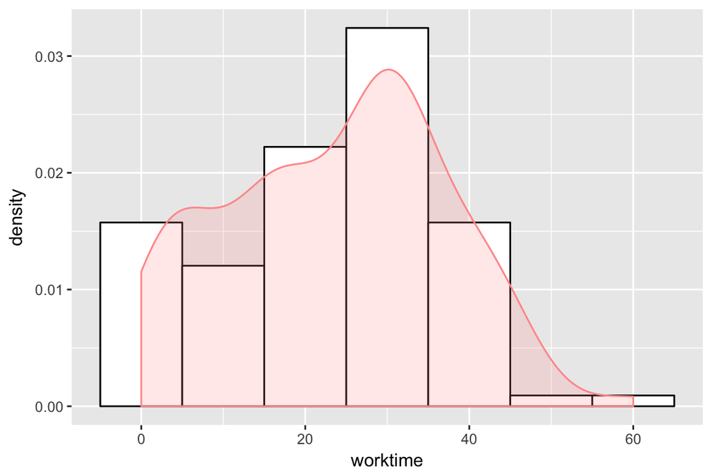

```r
ggplot(data, aes(x=worktime)) +
  geom_histogram(aes(y=..density..),# Histogram with density instead of count on y-axis
                 binwidth=10,
                 colour="black", fill="white") +
  geom_density(alpha=.2, fill="#FF9999", colour="#FF9999")  # Overlay with transparent density plot
```

The results portray that the density makes a peak around 30 months, that would be around 2.5 years. The maximum working time seems to be 5 years, that indicates that the company is relatively young.

After taking a look at the demographic data, let’s move on the the next section and start with 2.1 where we will see the activities that users are involved in the company. First, we want to create a data frame for easier exploration:

Now we can explore it with a bar graph:

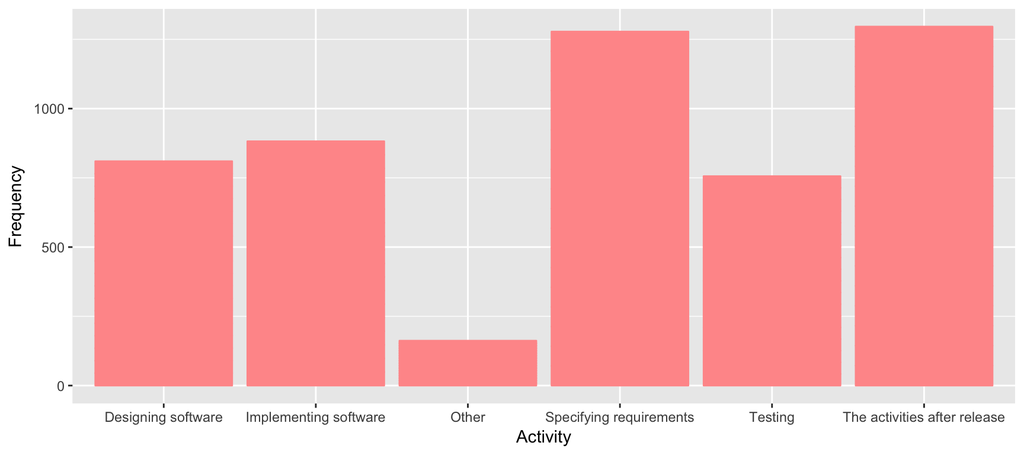

```r
ggplot(data=useractivities, aes(x=Activity, y=Frequency)) +
  geom_bar(stat="identity", fill="#FF9999", colour="#FF9999")
```

The graph above on user activities (Question 2.1) shows that the activities performed after a software release is the most common stage indicated by the respondents where the users are involved. Specifying the requirements is second most common activity where the users are involved, and it is followed by implementing the software.

Continuing with the responses to Question 2.2 where respondents were asked to rank the statements about user involvement in software development from disagreement to agreement, we again first create an convenient data frame:

Then we look at the data with a boxplot:

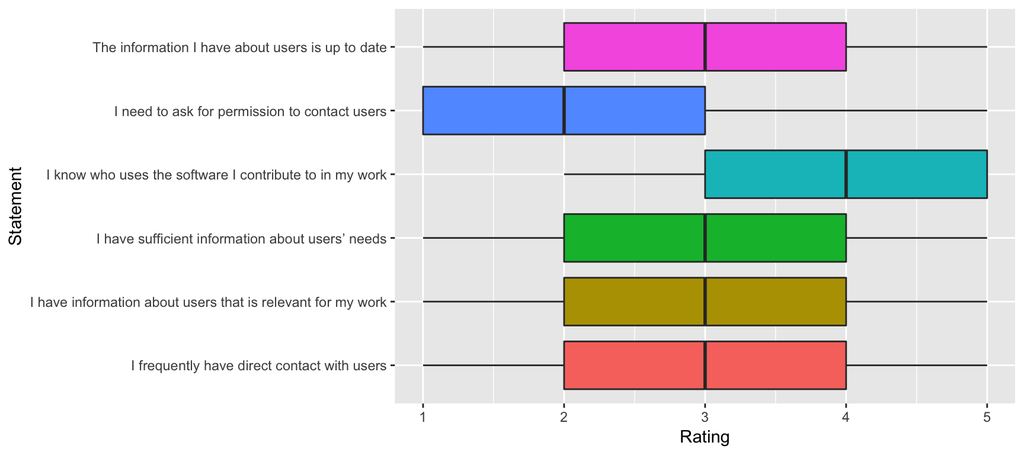

```r
ggplot(data=userinv, aes(x=Statement, y=Rating, fill=Statement)) +
  geom_boxplot() + guides(fill=FALSE) + coord_flip()
```

The figure above shows the statements about general user involvement in the companies vs. the ratings. where 1 is complete disagreement and 5 in complete agreement. We see that it was disagreed that respondents need to ask permission to contact users according to the median, whereas it was agreed that respondents know who uses the software they contribute to in their work. The other statements are on the neutral side, therefore we will need to look deeper into those in the next section. Also, we will try to understand if any significant correlations exist among the job functions, user activities and/or user involvement statements.

### 4 - Further analysis and Interpretations

Here, we can look into more visualizations with multiple variables in order to interpret the survey responses better.

First, for instance we could look at job functions with respect to age distributions:

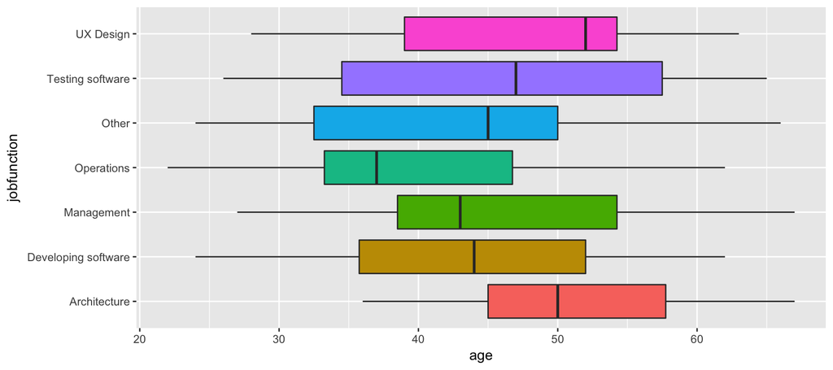

```r
ggplot(data,aes(x=jobfunction,y=age, fill=jobfunction))+geom_boxplot() + guides(fill=FALSE) + coord_flip()
```

The graph above is self-descriptive. Then, we could look into people who rated for ‘user avtivities after release’ with regards to job function distributions, as it was the activity ranked by the highest number of people:

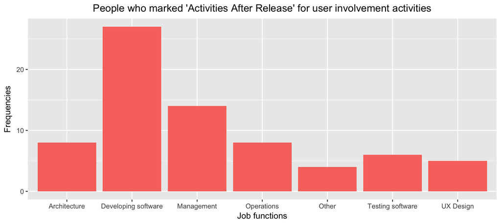

```r
cc <- table(data$jobfunction, data$useractivities.after.release)
cc<-data.frame(cc)
ccc <- cc[cc$Var2 == "TRUE",]
ggplot(ccc, aes(x=Var1,y=Freq,fill=Var2))+geom_bar(stat="identity") + labs(x="Job functions",y="Frequencies", title="People who marked 'Activities After Release' for user involvement activities") + theme(plot.title = element_text(hjust = 0.5))+guides(fill=FALSE) + theme(plot.title = element_text(lineheight=.6))
```

We see that software developers are the ones who ranked for this activity the most, followed by the managers. This is important to learn, because we are trying to understand whether managers think about user involvement differently than more technical people in the company.

Next, as we discussed in section 3, the same survey question (2.2) have not given much insigths into some of the stamements. Now we can look into the all job function distribution over the responses in one graph:

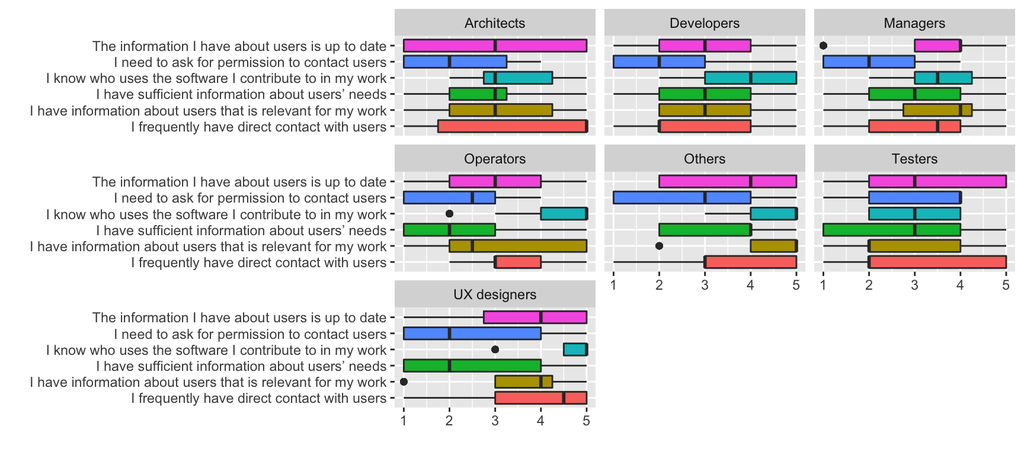

```r
jb_names <- c(
  'Developing software' = "Developers",
  'Testing software' = "Testers",
  'UX Design' = "UX designers",
  'Management' = "Managers",
  'Architecture' = "Architects",
  'Operations' = "Operators",
  'Other' = "Others"
)
ggplot(userinv,aes(x=Statement,y=Rating, fill=Rating))+ geom_boxplot(aes(fill = Statement)) + guides(fill=FALSE) + coord_flip() + scale_size_continuous(range = c(0, 70)) + facet_wrap(~data$jobfunction, labeller = as_labeller(jb_names)) +  labs(x = "", y = "")
```

Here we see interesting differences among different roles. For instance, developers and testers state that they do not have direct contact with users, whereas UX and arhitecture roles do have good contact. In general, since the companys had stated that testers and devvelopers receive the same information about users, results are consistent. In addition, we do not see major difference in managers’ responses with regards to the rest of the roles. Managers think that they have good access to the users and have up to date information. UX designers seem to be the closest to the users and holding updated and relevant information. They do not think that they need to ask for permission to contact users, however, they think that the information they hold might not be sufficient enough. This could indicate that they would like to improve their methods to get information about users.

We could also try to look at some correlations, here is a random one:

```r
cor(data$age, data$X1.1.Which.of.the.following.most.closely.matches.your.primary.job.function..)
```

```
## [1] 0.09384347
```

There seem not to be a good correlation between age and different roles in the company. Instead of checking each correlations manually, we can try to create an aggregated way of checking all the correlation among the numerical variables:

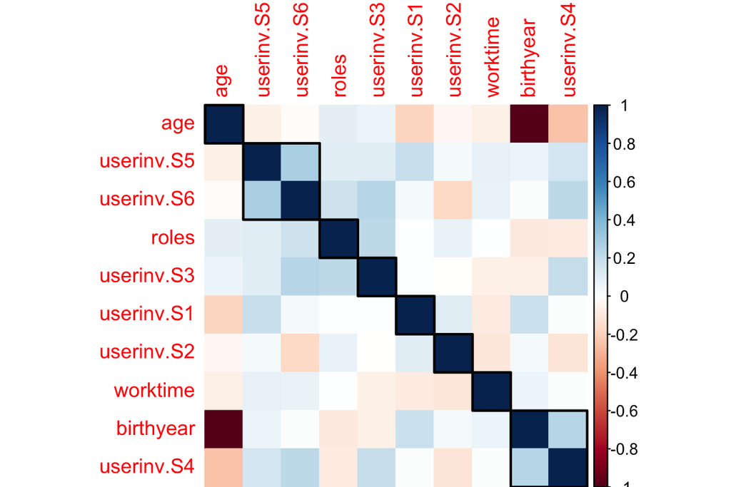

```r
roles <- data$X1.1.Which.of.the.following.most.closely.matches.your.primary.job.function..
corr_subset <- data[, 17:35]
corr_subset$roles = roles
corr_subset <- corr_subset[ ,c(ncol(corr_subset),1:(ncol(corr_subset)-1))] #adding roles column and bring it to the front
numeric_subset <- corr_subset[sapply(corr_subset, is.numeric)]
numeric_subset_corr<-cor(numeric_subset, use="pairwise.complete.obs")
corrplot(numeric_subset_corr, method= "color", order="hclust", addrect=8)
```

Birthyear and age seems to be perfectly reserve-correlated :) I think we are on the right track. In the question 2.2, statements 5 and 6 seems to be correlated, which are “I have information about users that are relevant to my work” and “The information I have about users is up to date”. These statements are consistent. Interestingly, birthyear an statement 4, that is “I have sufficient information about users” also seem to be a bit correlated, however not so significant to look into further.

### 5 - Conclusions and Discussion

Even though the complete analysis of the survey is not done yet, the initial results already demonstrates interesting remarks. For instance, activities after release and specifying the requirements are the most common activities indicated by the respondents where the users are involved in software development. On the other hand, different roles/job functions show different distributions over the statements regarding, for instance, how often users are contacted, how much information is collected and the relevancy of the information. The people’s agreement with these statements further should be cross-checked with the software development activities where the users are involved.

As the survey involved additional questions that were not yet analyzed yet, the initial results will also provide basis for cross-analysis of the whole survey. Besides, checking the correlations for the rest of the survey will validate the consistency of the respondents’ rankings as the future research. In conclusion, the results of the survey will be used to improve the company’s tools and methods to involve users into their development. Besides, when the survey is conducted by other companies, company-wise comparisons will be done, which will suggest new improvements for overall software development in companies and in research in Finland.